# LWT Data Exploration

install.packages(“curl”) install.packages(“dplyr”) install.packages(“tidyverse”) install.packages(“gplots”) install.packages(“corrplot”) install.packages(“ggplot2”)

```r
library(curl)
library(dplyr)
library(tidyverse)
```

```r
library(gplots)
library(corrplot)
library(ggplot2)
```

## Just playing with my full dataset

```r
vervets_original<- curl("https://raw.githubusercontent.com/langley1/Vervet-Data/master/Vervet%20Behavior.csv")
vervets_original<- read.csv(vervets_original, header = TRUE)
head(vervets_original)
```

```
##   Day Month Poop.collected.y.n AM.PM Weather   Loc.Desc Scan.time Age Sex
## 1  11  June                  Y    AM   SC LW F HO CG PW      6:00   I   U
## 2  11  June                  Y    AM   SC LW F HO CG PW      6:00   A   F
## 3  11  June                  Y    AM   SC LW         HO      6:10   I   U
## 4  11  June                  Y    AM   SC LW         HO      6:10   J   U
## 5  11  June                  Y    AM   SC LW         HO      6:10   I   U
## 6  11  June                  Y    AM   SC LW         HO      6:10   A   F
##   Strata Behavior Descriptor Location Interactions Food.Source
## 1     TC        L          0        F           NA          NA
## 2     MC       A+         IT        F           NA          NA
## 3     MC        R          0        F           NA          NA
## 4     MC       Fe        HFg       HO           NA          NA
## 5      G       Fo        HFg       HO           NA          NA
## 6      G       Fo        HFg       HO           NA          NA
```

```r
nrow(vervets_original)
```

```
## [1] 1048575
```

```r
summary(vervets_original)
```

```
##       Day           Month         Poop.collected.y.n AM.PM
##  Min.   : 1.0          :1038058    :1048396            :1047287
##  1st Qu.:12.0      July:   5775   Y:    179          AM:    739
##  Median :16.0      June:   4742                      PM:    549
##  Mean   :16.2
##  3rd Qu.:22.0
##  Max.   :30.0
##  NA's   :1038058
##     Weather                     Loc.Desc         Scan.time       Age
##         :1038058                    :1042240          :1038058    :1038058
##  NC     :   3083   Office           :    569   14:00  :    129   A:   3570
##  MC     :   2120   WOODLANDS GARBAGE:    441   14:35  :    128   F:      1
##  LW SC  :   2064   Woodlands Garbage:    414   16:00  :    127   I:   3337
##  SC     :   1004   Woodlands Grounds:    359   16:30  :    125   J:   3608
##  LW MC  :    713   CENTER GROUNDS   :    353   16:45  :    125   U:      1
##  (Other):   1533   (Other)          :   4199   (Other):   9883
##  Sex             Strata           Behavior         Descriptor
##   :1038058          :1038058          :1038058          :1038064
##  F:   2389   G      :   6280   R      :   2907   0      :   7212
##  I:      1   MC     :   2823   L      :   2775   HFg    :   1853
##  J:      4   HCS    :    632   Fo     :   2264   N      :   1121
##  M:   1556   HS     :    594   PL     :   1073   Sed    :    184
##  U:   6567   TC     :    168   Fe     :   1048   HFn    :     68
##              (Other):     20   (Other):    450   (Other):     73
##     Location       Interactions   Food.Source
##         :1038058   Mode:logical   Mode:logical
##  Ln     :   2282   NA's:1048575   NA's:1048575
##  F      :   2175
##  GP     :   1311
##  PW     :    798
##  CP     :    588
##  (Other):   3363
```

```r
names(vervets_original)
```

```
##  [1] "Day"                "Month"              "Poop.collected.y.n"
##  [4] "AM.PM"              "Weather"            "Loc.Desc"
##  [7] "Scan.time"          "Age"                "Sex"
## [10] "Strata"             "Behavior"           "Descriptor"
## [13] "Location"           "Interactions"       "Food.Source"
```

```r
unique(vervets_original$Location)
```

```
##  [1] F    HO   Ln   PW   CP   RV   PL   RO   RF   RS   CG   Oeb  Ied  Oed  PG
## [16] Gr   GP   WG   GG   G    HS   Ied  Oep  N    RB   HCS  ES   GR
## 29 Levels:  CG CP ES F G GG GP Gr GR HCS HO HS Ied Ied  Ln N Oeb Oed Oep ... WG
```

```r
unique(vervets_original$Age)
```

```
## [1] I A J U F
## Levels:  A F I J U
```

```r
sort(table(vervets_original$Behavior), decreasing = TRUE)
```

```
##
##               R       L      Fo      PL      Fe     Gr-     Gr+      Dr     Ag+
## 1038058    2907    2775    2264    1073    1048     175     158      31      14
##      G+     Th+      PA      G-      A+     Ag-     Th-      MC       r      A-
##      11      11      10       8       7       7       4       3       3       2
##      CP      SG      Fp       U
##       2       2       1       1
```

## Importing Updated Dataset with edits given by Olivia

```r
vervets_full<- curl("https://raw.githubusercontent.com/langley1/Vervet-Data/master/LWT%20Vervet%20Dataset_Updated.csv")
vervets_full<- read.csv(vervets_full, header = TRUE)
head(vervets_full)
```

```
##   Day Month Poop.collected.y.n AM.PM Weather   Loc.Desc Scan.time Age Sex
## 1  11  June                  Y    AM   SC LW F HO CG PW      6:00   I   U
## 2  11  June                  Y    AM   SC LW F HO CG PW      6:00   A   F
## 3  11  June                  Y    AM   SC LW         HO      6:10   I   U
## 4  11  June                  Y    AM   SC LW         HO      6:10   J   U
## 5  11  June                  Y    AM   SC LW         HO      6:10   I   U
## 6  11  June                  Y    AM   SC LW         HO      6:10   A   F
##   Strata Behavior Descriptor Location
## 1     TC        L          0        F
## 2     MC      Ag+         IT        F
## 3     MC        R          0        F
## 4     MC       Fe        HFg       HO
## 5      G       Fo        HFg       HO
## 6      G       Fo        HFg       HO
```

```r
str(vervets_full)
```

```
## 'data.frame':    10517 obs. of  13 variables:
##  $ Day               : int  11 11 11 11 11 11 11 11 11 11 ...
##  $ Month             : Factor w/ 2 levels "July","June": 2 2 2 2 2 2 2 2 2 2 ...
##  $ Poop.collected.y.n: Factor w/ 2 levels "","Y": 2 2 2 2 2 2 2 2 2 2 ...
##  $ AM.PM             : Factor w/ 3 levels "","AM","PM": 2 2 2 2 2 2 2 2 2 2 ...
##  $ Weather           : Factor w/ 12 levels "50%","C","C LW",..: 12 12 12 12 12 12 12 12 12 12 ...
##  $ Loc.Desc          : Factor w/ 80 levels "","BIRD ENCLOSURE",..: 15 15 29 29 29 29 29 29 29 29 ...
##  $ Scan.time         : Factor w/ 142 levels "10:00","10:05",..: 95 95 97 97 97 97 97 97 97 97 ...
##  $ Age               : Factor w/ 4 levels "A","I","J","U": 2 1 2 3 2 1 2 3 1 2 ...
##  $ Sex               : Factor w/ 3 levels "F","M","U": 3 1 3 3 3 1 3 3 1 3 ...
##  $ Strata            : Factor w/ 7 levels "Fo","G","HCS",..: 7 5 5 5 2 2 6 5 5 5 ...
##  $ Behavior          : Factor w/ 17 levels "Ag-","Ag+","CP",..: 9 2 13 5 6 6 13 13 13 1 ...
##  $ Descriptor        : Factor w/ 15 levels "0","Cr","H","HF",..: 1 8 1 6 6 6 1 1 1 1 ...
##  $ Location          : Factor w/ 19 levels "CG","CP","F",..: 3 3 3 6 6 6 6 6 6 6 ...
```

```r
summary(vervets_full)
```

```
##       Day         Month      Poop.collected.y.n AM.PM        Weather
##  Min.   : 1.00   July:5775    :10338              :9229   NC     :3083
##  1st Qu.:12.00   June:4742   Y:  179            AM: 739   MC     :2120
##  Median :16.00                                  PM: 549   LW SC  :2064
##  Mean   :16.22                                            SC     :1004
##  3rd Qu.:22.00                                            LW MC  : 713
##  Max.   :30.00                                            C      : 637
##                                                           (Other): 896
##               Loc.Desc      Scan.time    Age      Sex      Strata
##                   :4182   14:00  : 129   A:3570   F:2389   Fo :   2
##  Office           : 569   14:35  : 128   I:3337   M:1556   G  :6280
##  WOODLANDS GARBAGE: 441   16:00  : 127   J:3608   U:6572   HCS: 632
##  Woodlands Garbage: 414   16:30  : 125   U:   2            HS : 594
##  Woodlands Grounds: 359   16:45  : 125                     MC :2826
##  CENTER GROUNDS   : 353   12:45  : 123                     R  :  15
##  (Other)          :4199   (Other):9760                     TC : 168
##     Behavior      Descriptor      Location
##  R      :2908   0      :7218   Ln     :2282
##  L      :2777   HFg    :1853   F      :2176
##  Fo     :2264   N      :1121   GP     :1313
##  PL     :1073   Sed    : 184   PW     : 818
##  Fe     :1049   HFn    :  68   CP     : 595
##  G-     : 183   HF     :  25   RS     : 551
##  (Other): 263   (Other):  48   (Other):2782
```

## Creating unique IDs for each scan sample

```r
vervets_full<- vervets_full %>% unite("Scan.info", Day, Month, Scan.time, sep = "_", remove = FALSE)  #this unites the 3 columns, (day, month, scan time) into one column called "Scan.info" so that I can create an ID based on each unique scan
vervets_full<- transform(vervets_full, ScanID= as.numeric(factor(Scan.info))) #this creates a new column called "ScanID" and assigns its #s based on the Scan.info column

tail(levels(factor(vervets_full$ScanID))) #There are a total of 1168 scans
```

```
## [1] "1163" "1164" "1165" "1166" "1167" "1168"
```

## Breaking up the food into different categories and creating dfs for each

```r
food_HF<- vervets_full %>% filter(Descriptor %in% c("HF", "HFn", "HFg", "HFc", "Cr")) #human food and crops
food_SE<- vervets_full %>% filter(Descriptor %in% c("Sep", "Sed")) #Spilled enclosure food
food_Nat<- vervets_full %>% filter(Descriptor %in% c("N", "RV", "R")) #Natural and river
food_Water<- vervets_full %>% filter(Descriptor %in% c("ST", "H", "WT")) #sewage, hose, water

#Creating a new column called Descriptor Cateogory for the food groupings
food_HF$Descriptor.Cat<- "HF"
food_SE$Descriptor.Cat<- "SE"
food_Nat$Descriptor.Cat<- "NRV"
food_Water$Descriptor.Cat<- "W"

#Combing all of my dfs into one so that I can plot it by the Descript.Cat. Column
food_desc_ALL<- rbind(food_HF, food_SE, food_Nat, food_Water)
unique(food_desc_ALL$Descriptor.Cat)
```

```
## [1] "HF"  "SE"  "NRV" "W"
```

## Plotting the food groupings

### *by Age*

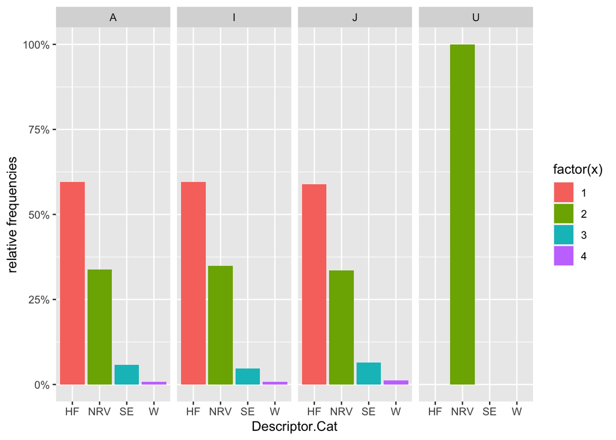

```r
food_age_plot <- ggplot(food_desc_ALL, aes(Descriptor.Cat, group = Age)) +
          geom_bar(aes(y = ..prop.., fill = factor(..x..)), stat="count") +
          scale_y_continuous(labels=scales::percent) +
          ylab("relative frequencies") +
          facet_grid(~Age)
food_age_plot
```

### *by Sex*

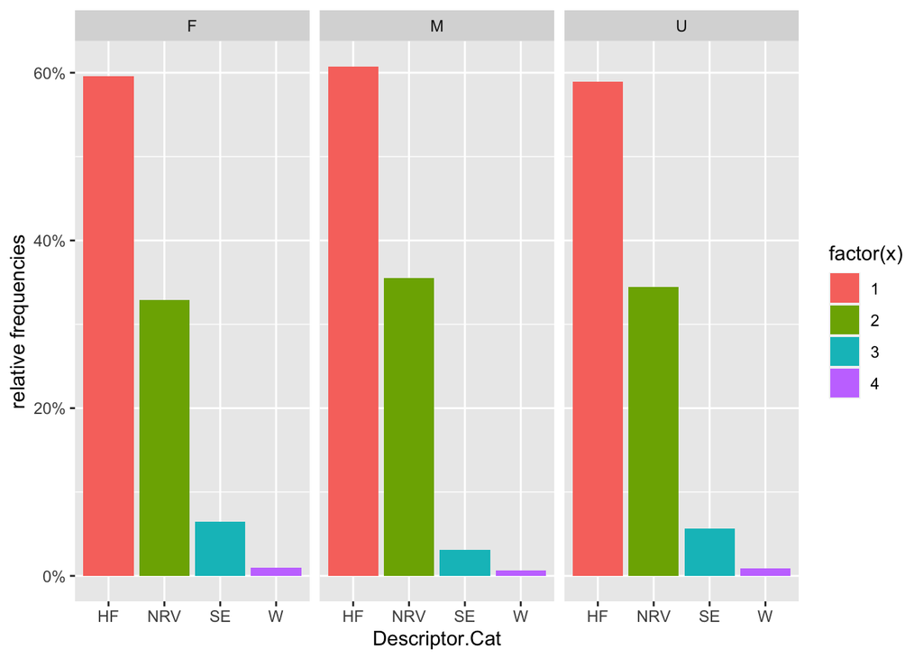

```r
food_sex_plot <- ggplot(food_desc_ALL, aes(Descriptor.Cat, group = Sex)) +
          geom_bar(aes(y = ..prop.., fill = factor(..x..)), stat="count") +
          scale_y_continuous(labels=scales::percent) +
          ylab("relative frequencies") +
          facet_grid(~Sex)
food_sex_plot
```

## Breaking up the locations into High/Medium/Low Human Interactions (as recommended by Olivia) and adding a new column

```r
high_human<- vervets_full %>% filter(Location %in% c("HO", "PG", "RO", "RS"))
med_human<- vervets_full %>% filter(Location %in% c("CG", "CP", "GP", "Ln", "PW", "WG"))
low_human<- vervets_full %>% filter(Location %in% c("F", "RF", "RB", "RV", "Oeb", "Oed", "Oep", "Ied"))

high_human$HumanLevel<- "H"
med_human$HumanLevel<- "M"
low_human$HumanLevel<- "L"

nrow(high_human) #1818
```

```
## [1] 1818
```

```r
nrow(med_human) #5199
```

```
## [1] 5199
```

```r
nrow(low_human) #3499
```

```
## [1] 3499
```

## Counting up the number of different behaviors in each group (high/med/low) in descending order

```r
high_human_behaviorcount<- high_human %>%
  group_by(Behavior) %>%
  summarize(count=n()) %>%
  arrange(desc(count))
nrow(high_human_behaviorcount) #13 behaviors (should Ag+/-, Th+/-, G+/-, etc. be counted as two different behaviors or just one?)
```

```
## [1] 13
```

```r
high_human_behaviorcount<- high_human %>%
  group_by(Behavior, ScanID) %>%
  summarize(count=n()) %>%
  arrange(desc(count))

med_human_behaviorcount<- med_human %>%
  group_by(Behavior) %>%
  summarize(count=n()) %>%
  arrange(desc(count))
nrow(med_human_behaviorcount) #14 behaviors
```

```
## [1] 14
```

```r
low_human_behaviorcount<- low_human %>%
  group_by(Behavior) %>%
  summarize(count=n()) %>%
  arrange(desc(count))
nrow(low_human_behaviorcount) #13 behaviors
```

```
## [1] 13
```

```r
#Overall, there are roughly the same total number of unique behaviors seen across the three location categories- human level doesn't seem to affect behavioral diversity
```

## Finding the proportion of Adult Female behavior occurences in **high human** category

### *Total*

```r
AF_high_human<- high_human %>% filter(Age == "A", Sex == "F")
head(AF_high_human) #408 rows
```

```
##      Scan.info Day Month Poop.collected.y.n AM.PM Weather Loc.Desc Scan.time
## 1 11_June_6:10  11  June                  Y    AM   SC LW       HO      6:10
## 2 11_June_6:10  11  June                  Y    AM   SC LW       HO      6:10
## 3 11_June_6:10  11  June                  Y    AM   SC LW       HO      6:10
## 4 11_June_6:20  11  June                  Y    AM   SC LW       HO      6:20
## 5 11_June_6:20  11  June                  Y    AM   SC LW       HO      6:20
## 6 11_June_6:20  11  June                  Y    AM   SC LW       HO      6:20
##   Age Sex Strata Behavior Descriptor Location ScanID HumanLevel
## 1   A   F      G       Fo        HFg       HO    136          H
## 2   A   F     MC        R          0       HO    136          H
## 3   A   F     MC      Ag+          0       HO    136          H
## 4   A   F    HCS       Fe        HFn       HO    137          H
## 5   A   F      G       Fo        HFg       HO    137          H
## 6   A   F      G       Fo        HFg       HO    137          H
```

### *Feeding/foraging*

```r
AF_Fe_high_human<- high_human %>% filter(Age == "A", Sex == "F", Behavior %in% c("Fe", "Fo"))
head(AF_Fe_high_human) #179 rows
```

```
##      Scan.info Day Month Poop.collected.y.n AM.PM Weather Loc.Desc Scan.time
## 1 11_June_6:10  11  June                  Y    AM   SC LW       HO      6:10
## 2 11_June_6:20  11  June                  Y    AM   SC LW       HO      6:20
## 3 11_June_6:20  11  June                  Y    AM   SC LW       HO      6:20
## 4 11_June_6:20  11  June                  Y    AM   SC LW       HO      6:20
## 5 11_June_6:30  11  June                  Y    AM   SC LW       HO      6:30
## 6 11_June_6:30  11  June                  Y    AM   SC LW       HO      6:30
##   Age Sex Strata Behavior Descriptor Location ScanID HumanLevel
## 1   A   F      G       Fo        HFg       HO    136          H
## 2   A   F    HCS       Fe        HFn       HO    137          H
## 3   A   F      G       Fo        HFg       HO    137          H
## 4   A   F      G       Fo        HFg       HO    137          H
## 5   A   F      G       Fe        HFg       HO    138          H
## 6   A   F    HCS       Fe         HF       HO    138          H
```

```r
prop_AF_Fe_high_human<- (nrow(AF_Fe_high_human)/nrow(AF_high_human))*100
prop_AF_Fe_high_human #43.87
```

```
## [1] 43.87255
```